# Movie Recommendation Group Project

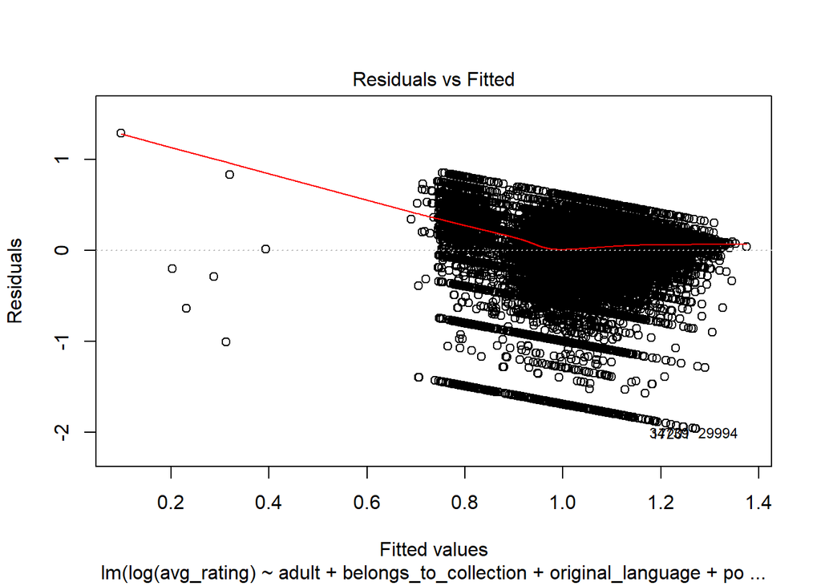

```r
plot(log,which=1)
```

```r
# glm first try
logReg1 = glm(goodScore ~ adult+ belongs_to_collection  + original_language + popularity + production_companies+runtime+vote_average+release_year+profit,dataset1,family=binomial)
summary(logReg1)
```

```
##
## Call:
## glm(formula = goodScore ~ adult + belongs_to_collection + original_language +
##     popularity + production_companies + runtime + vote_average +
##     release_year + profit, family = binomial, data = dataset1)
##
## Deviance Residuals:
##     Min       1Q   Median       3Q      Max
## -0.6551  -0.4293  -0.3896  -0.2937   3.5186
##
## Coefficients: (1 not defined because of singularities)
##                                Estimate Std. Error z value Pr(>|z|)
## (Intercept)                  -9.973e+00  1.718e+00  -5.805 6.45e-09 ***
## adult                         6.494e-01  1.088e+00   0.597 0.550554
## belongs_to_collection        -1.023e-01  8.395e-02  -1.219 0.222821
## original_languageNon English  1.444e-01  4.364e-02   3.309 0.000935 ***
## popularity                   -2.021e-01  1.322e-02 -15.287  < 2e-16 ***
## production_companies                 NA         NA      NA       NA
## runtime                      -2.737e-03  6.251e-04  -4.379 1.19e-05 ***
## vote_average                  8.035e-03  1.016e-02   0.790 0.429239
## release_year                  3.965e-03  8.636e-04   4.592 4.40e-06 ***
## profit                       -4.642e-10  3.156e-09  -0.147 0.883074
## ---
## Signif. codes:  0 '***' 0.001 '**' 0.01 '*' 0.05 '.' 0.1 ' ' 1
##
## (Dispersion parameter for binomial family taken to be 1)
##
##     Null deviance: 18835  on 36921  degrees of freedom
## Residual deviance: 18310  on 36913  degrees of freedom
## AIC: 18328
##
## Number of Fisher Scoring iterations: 6
```

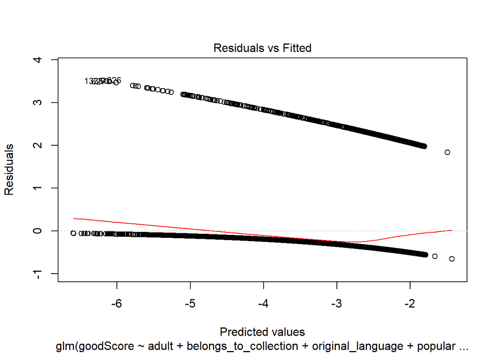

```r
plot(logReg1,which=1)
```

```r
# glm second try
logReg2 = glm(goodScore ~  belongs_to_collection  + original_language + popularity +I(popularity^2)+runtime+vote_average+release_year+profit,dataset1,family=binomial)
summary(logReg2)
```

```
##
## Call:
## glm(formula = goodScore ~ belongs_to_collection + original_language +
##     popularity + I(popularity^2) + runtime + vote_average + release_year +
##     profit, family = binomial, data = dataset1)
##
## Deviance Residuals:
##     Min       1Q   Median       3Q      Max
## -1.7215  -0.4466  -0.3740  -0.2309   3.1494
##
## Coefficients:
##                                Estimate Std. Error z value Pr(>|z|)
## (Intercept)                  -1.170e+01  1.731e+00  -6.760 1.38e-11 ***
## belongs_to_collection        -3.948e-03  8.510e-02  -0.046  0.96300
## original_languageNon English  1.389e-01  4.384e-02   3.169  0.00153 **
## popularity                   -5.429e-01  2.344e-02 -23.162  < 2e-16 ***
## I(popularity^2)               3.299e-02  1.598e-03  20.648  < 2e-16 ***
## runtime                      -1.706e-03  6.255e-04  -2.728  0.00637 **
## vote_average                  3.093e-02  9.989e-03   3.096  0.00196 **
## release_year                  4.845e-03  8.702e-04   5.567 2.59e-08 ***
## profit                       -6.929e-09  3.533e-09  -1.961  0.04984 *
## ---
## Signif. codes:  0 '***' 0.001 '**' 0.01 '*' 0.05 '.' 0.1 ' ' 1
##
## (Dispersion parameter for binomial family taken to be 1)
##
##     Null deviance: 18835  on 36921  degrees of freedom
## Residual deviance: 17974  on 36913  degrees of freedom
## AIC: 17992
##
## Number of Fisher Scoring iterations: 6
```

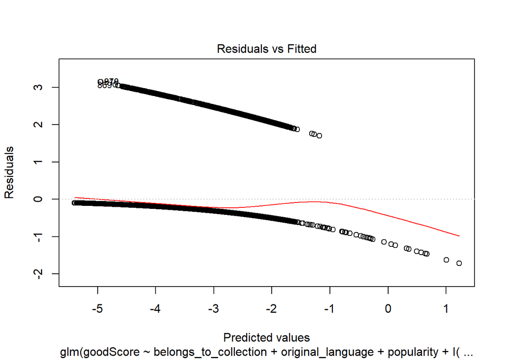

```r
plot(logReg2,which=1)
```

```r
# glm third try (Final decision)
logReg3 = glm(goodScore ~  popularity +runtime + release_year + budget + production_countries,dataset1,family=binomial)
summary(logReg3)
```

```
##
## Call:
## glm(formula = goodScore ~ popularity + runtime + release_year +
##     budget + production_countries, family = binomial, data = dataset1)
##
## Deviance Residuals:
##     Min       1Q   Median       3Q      Max
## -0.5388  -0.4411  -0.3726  -0.2923   3.4310
##
## Coefficients:
##                              Estimate Std. Error z value Pr(>|z|)
## (Intercept)                -7.034e+00  1.756e+00  -4.007 6.15e-05 ***
## popularity                 -1.693e-01  1.265e-02 -13.386  < 2e-16 ***
## runtime                    -2.474e-03  6.147e-04  -4.024 5.72e-05 ***
## release_year                2.366e-03  8.868e-04   2.668  0.00762 **
## budget                     -3.307e-08  1.255e-08  -2.636  0.00839 **
## production_countriesNon US  4.137e-01  4.649e-02   8.899  < 2e-16 ***
## ---
## Signif. codes:  0 '***' 0.001 '**' 0.01 '*' 0.05 '.' 0.1 ' ' 1
##
## (Dispersion parameter for binomial family taken to be 1)
##
##     Null deviance: 18835  on 36921  degrees of freedom
## Residual deviance: 18229  on 36916  degrees of freedom
## AIC: 18241
##
## Number of Fisher Scoring iterations: 7
```

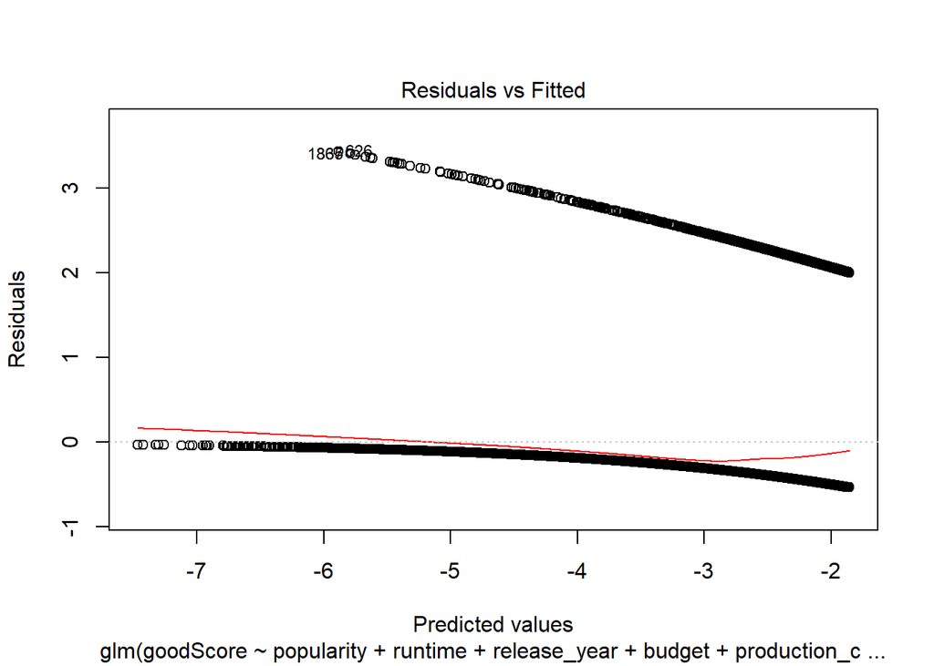

```r
plot(logReg3,which=1)
```

```r
# figure out the model accuracy

# Psuedo R-squared
logRegFin = logReg3
1 - logRegFin$deviance/logRegFin$null.deviance
```

```
## [1] 0.03217692
```

```r
# Classification Matrix
pred = predict(logRegFin,type="response")
pred[pred>=.5] = "goodScore"
pred[pred!="goodScore"] = "badScore"
classMatrix = table(pred,dataset1$goodScore)
classMatrix
```

```
##
## pred           0     1
##   badScore 34317  2605
```

```r
# good/bad prediction accuracy rate
sum(diag(classMatrix))/sum(classMatrix)
```

```
## [1] 0.9294459
```

## Use Cases

After observing and predicting history movie data, we recommend that the users should choose the movies that have last 10% popularity, last 10% budget, last 10% runtime, top 10% release year and are produced in non-us countries considering the negative and positive effects on showing probability of good movie.  
In other words, if the users see a non-us movie that has popularity lower than 0.078, budget equals to 0, runtime less than 62 and is later than 2014, there is relatively large 12% probability that this movie is a good movie and has the high average rating greater than 4.